# VU [183.653](https://tiss.tuwien.ac.at/course/courseDetails.xhtml?courseNr=183653) Methodical, industrial Software-Engineering using the Haskell **fun**ctional programming language

Pre-Meeting

2013-03-11

# What's this course about?

- Learning how to apply **functional programming** techniques for building industrial-grade systems.
- Learning what facilities Haskell offers over traditionally deployed languages for building **robust** software.
- Learning about GHC internals in order to be able to reason about **performance** and resource usage of Haskell programs.
- Applying some of the concepts shown in this course in a **project of your own choice**.

# Why Haskell?

- Small language core
- **Expressive** power (⇒ reduces accidental complexity)
- **Lazy** evaluation (⇒ infinite data structures, composability, EDSLs, extensions as libraries)
- Advanced **static type-system** (⇒ correctness)
- **Purely functional** (⇒ correctness)
- **Immutable** data (⇒ correctness)
- Built-in support for various models of **concurrency** and **parallelism**
- Can be compiled (⇒ performance) as well as interpreted (⇒ speedy development)

# Why Haskell? *(cont.)*

- Haskell is actively researched and developed (stolen from Simon P. Jones):

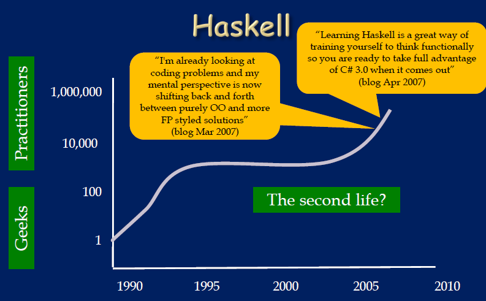

# Why (not) Haskell?

- It's not Java
- It's old (even older than Java)
- It's not object-oriented
- It requires to learn many "new" things
- Well, it's different... so what?  
  *"A language that doesn't affect the way you think about programming, is not worth knowing."* - Alan Perlis  
  *"Die Grenzen meiner Sprache bedeuten die Grenzen meiner Welt."* - Ludwig Wittgenstein

# Haskell's popularity

[figure not shown]

# Case Study: ÖBB Ticketing

[figure not shown]

ÖBB's new online & mobile ticketing system for the austrian railway

# Case Study: ÖBB Ticketing *(cont.)*

- Collection of components talking to each other via web-service calls (*SOA*)
- Some of the backend components are implemented in Haskell, most notably the central **offer/fare calculation engine**:
  - Given a set of *objects* ("it's people!") to be conveyed and
  - a list of *connections* (as provided by the time-table service),
  - this component computes optimal offers in accordance with the *product definition database*
  - while taking into account dynamic information such as seat reservation and contingent availability.
- One of the most complex components and yet **no major bugs known** since go-live last year

# Your own project!

- Consists of a Haskell-related project of your choice
  - Form project team of 1-3 people and agree on a project idea
  - You may reuse project from a different class
  - Submit your project proposal ASAP
- Don't hesistate to ask for help/guidance if you're stuck on a Haskell problem
- Getting a grade requires your team to present your work at the end of this course
  - Self-evaluate your project experience (the good things as well as the problems that you encountered).
  - Compare to traditional implementation techniques (e.g. Java).
  - Submit a short paper (will be distributed to other students)
  - ...and finally give a short presentation (about 15 minutes) and be prepared to respond to questions from the audience afterwards.

# Administrativa

- First lecture: Next Monday (= 18.03.2013) in **HS14** starting at 16:00 **s.t.** (that's here!)
- A few lectures will (probably) take place in **S325/2** (see TISS for details)
- Please register for this course at TISS so we can inform you about any relocations and other changes in the schedule.
- Questions?